# Gene sets in R

Jeff Leek

## Dependencies

This document depends on the following packages:

```r
  library(devtools)
  library(Biobase)
  library(goseq)
  library(DESeq2)
```

To install these packages you can use the code (or if you are compiling the document, remove the `eval=FALSE` from the chunk.)

```r
install.packages(c("devtools","MatrixEQTL"))
source("http://www.bioconductor.org/biocLite.R")
biocLite(c("Biobase","goseq","DESeq2"))
```

## Download the data

Here we are going to follow along with the tutorial on [goseq](http://www.bioconductor.org/packages/release/bioc/vignettes/goseq/inst/doc/goseq.pdf). You can see what genomes are supported by this package

```r
head(supportedGenomes())
```

```
##        db species      date                                name
## 1    hg38   Human Dec. 2013  Genome Reference Consortium GRCh38
## 2    hg19   Human Feb. 2009  Genome Reference Consortium GRCh37
## 3    hg18   Human Mar. 2006                     NCBI Build 36.1
## 4    hg17   Human  May 2004                       NCBI Build 35
## 5    hg16   Human Jul. 2003                       NCBI Build 34
## 6 vicPac2  Alpaca Mar. 2013 Broad Institute Vicugna_pacos-2.0.1
##                                                                                                                    AvailableGeneIDs
## 1
## 2                                                      ccdsGene,ensGene,exoniphy,geneSymbol,knownGene,nscanGene,refGene,xenoRefGene
## 3   acembly,acescan,ccdsGene,ensGene,exoniphy,geneSymbol,geneid,genscan,knownGene,knownGeneOld3,refGene,sgpGene,sibGene,xenoRefGene
## 4 acembly,acescan,ccdsGene,ensGene,exoniphy,geneSymbol,geneid,genscan,knownGene,refGene,sgpGene,vegaGene,vegaPseudoGene,xenoRefGene
## 5                                                      acembly,ensGene,exoniphy,geneSymbol,geneid,genscan,knownGene,refGene,sgpGene
## 6
```

```r
head(supportedGeneIDs())
```

```
##              db          track           subtrack               GeneID
## 1     knownGene     UCSC Genes               <NA>       Entrez Gene ID
## 2 knownGeneOld3 Old UCSC Genes               <NA>
## 3      ccdsGene           CCDS               <NA>
## 4       refGene   RefSeq Genes               <NA>       Entrez Gene ID
## 5   xenoRefGene   Other RefSeq               <NA>
## 6      vegaGene     Vega Genes Vega Protein Genes HAVANA Pseudogene ID
##                                                                                                                                                                                                                                                                                                          …
## 1                                                                                                                                                                                                                                                                                                        …
## 2                                                                                                                                                                                                                                                                                                        …
## 3                                                                                                                                                                                                                                                                                                        …
## 4                                                                                                                                          bosTau2,bosTau3,bosTau4,canFam1,canFam2,ce2,ce4,ce6,ci1,ci2,danRer3,danRer4,danRer5,danRer6,dm1,dm2,dm3,equCab1,equCab2,felCat3,galGal2,galGal3,hg16,hg17,hg18…
## 5 anoCar1,aplCal1,braFlo1,caeJap1,caePb1,caePb2,caeRem2,caeRem3,calJac1,canFam1,canFam2,cavPor3,cb1,cb3,ce4,ce6,ci1,ci2,danRer6,dp2,dp3,droAna1,droAna2,droEre1,droGri1,droMoj1,droMoj2,droPer1,droSec1,droSim1,droVir1,droVir2,droYak1,droYak2,equCab2,felCat3,galGal3,hg17,hg18,hg19,loxAfr3,mm7,mm8,mm…
## 6                                                                                                                                                                                                                                                                                                        …
```

## An example of a goseq analysis

### Load the data

Here we load the example frmo the `goseq` package.

```r
temp_data =read.table(system.file("extdata","Li_sum.txt",
                                     package="goseq"),sep="\t",
                                     header=TRUE,
                                     stringsAsFactors=FALSE)
expr= temp_data[,-1]
rownames(expr) = temp_data[,1]
expr = expr[rowMeans(expr) > 5,]
grp=factor(rep(c("Control","Treated"),times=c(4,3)))
pdata  = data.frame(grp)
```

### Perform a differential expression analysis

Now we perform a differential expression analysis for the group variable with `DESeq2`

```r
de = DESeqDataSetFromMatrix(expr, pdata, ~grp)
de_fit = DESeq(de)
de_results = results(de_fit)
```

Get the differentially expressed genes after FDR correction

```r
genes = as.integer(de_results$padj < 0.05)
not_na = !is.na(genes)
names(genes) = rownames(expr)
genes = genes[not_na]
```

### Pick the right genome

Here we look at some of the automatically supported genomes

```r
head(supportedGenomes(),n=12)[,1:4]
```

```
##         db   species      date                                     name
## 1     hg38     Human Dec. 2013       Genome Reference Consortium GRCh38
## 2     hg19     Human Feb. 2009       Genome Reference Consortium GRCh37
## 3     hg18     Human Mar. 2006                          NCBI Build 36.1
## 4     hg17     Human  May 2004                            NCBI Build 35
## 5     hg16     Human Jul. 2003                            NCBI Build 34
## 6  vicPac2    Alpaca Mar. 2013      Broad Institute Vicugna_pacos-2.0.1
## 7  vicPac1    Alpaca Jul. 2008                Broad Institute VicPac1.0
## 8  dasNov3 Armadillo Dec. 2011                  Broad Institute DasNov3
## 9  otoGar3  Bushbaby Mar. 2011                  Broad Institute OtoGar3
## 10 papHam1    Baboon Nov. 2008 Baylor College of Medicine HGSC Pham_1.0
## 11 papAnu2    Baboon Mar. 2012      Baylor College of Medicine Panu_2.0
## 12 felCat5       Cat Sep. 2011                    ICGSC Felis_catus-6.2
```

We need to set up a weighting function for all the genes in that genome

```r
pwf=nullp(genes,"hg19","ensGene")
```

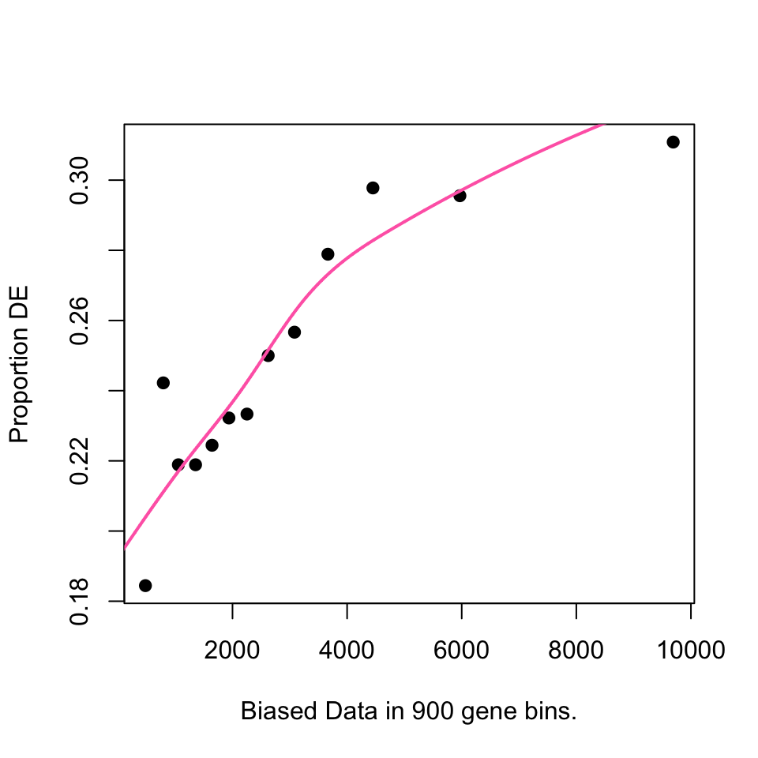

```r
head(pwf)
```

```
##                 DEgenes bias.data       pwf
## ENSG00000124208       0      1978 0.2362794
## ENSG00000224628       0      1510 0.2265504
## ENSG00000125835       0       954 0.2147844
## ENSG00000125834       0      6013 0.2972752
## ENSG00000197818       0      6295 0.2996675
## ENSG00000101181       0      2644 0.2520835
```

### Perform the enrichment analysis parametrically

Here we use a parametric test to look for differences in enrichment with respect to different categories. This is the 2 x 2 table approach. You can also use random sampling to define the null distribution by setting the parameters `method="Sampling"` and `repcnt=1000` for the number of null repititions.

```r
GO.wall=goseq(pwf,"hg19","ensGene")
head(GO.wall)
```

```
##        category over_represented_pvalue under_represented_pvalue
## 9656 GO:0044763            2.243186e-18                        1
## 9578 GO:0044421            2.244623e-18                        1
## 2058 GO:0005576            3.691127e-18                        1
## 6756 GO:0031982            6.248427e-18                        1
## 6761 GO:0031988            1.472125e-17                        1
## 9636 GO:0044699            5.082258e-17                        1
##      numDEInCat numInCat                             term ontology
## 9656       1750     5932 single-organism cellular process       BP
## 9578        616     1798        extracellular region part       CC
## 2058        654     1930             extracellular region       CC
## 6756        669     1984                          vesicle       CC
## 6761        651     1929         membrane-bounded vesicle       CC
## 9636       1894     6537          single-organism process       BP
```

### Limiting yourself to a single category you are interested in

Suppose there is a particular category or function you are interested in. You can limit to just that category

```r
GO.MF=goseq(pwf,"hg19","ensGene",test.cats=c("GO:MF"))
head(GO.MF)
```

```
##        category over_represented_pvalue under_represented_pvalue
## 909  GO:0005198            5.318741e-08                1.0000000
## 1004 GO:0005515            2.398716e-05                0.9999808
## 2566 GO:0044822            2.639927e-05                0.9999810
## 205  GO:0003723            6.656537e-05                0.9999495
## 1941 GO:0023023            1.045388e-04                0.9999963
## 1942 GO:0023026            1.045388e-04                0.9999963
##      numDEInCat numInCat                                 term ontology
## 909         129      334         structural molecule activity       MF
## 1004       1677     6006                      protein binding       MF
## 2566        322     1024                  poly(A) RNA binding       MF
## 205         395     1297                          RNA binding       MF
## 1941          8        9          MHC protein complex binding       MF
## 1942          8        9 MHC class II protein complex binding       MF
```

## More information

Gene set and other enrichment analyses are widely used to make sense of genomic results. Here are a couple of good places to start

- [geneontology website](http://geneontology.org/)
- [goseq vignette](http://www.bioconductor.org/packages/release/bioc/vignettes/goseq/inst/doc/goseq.pdf)
- [seqGSEA package](http://www.bioconductor.org/packages/release/bioc/html/SeqGSEA.html)
- [An early gene set enrichment paper](http://www.pnas.org/content/102/43/15545.full)

## Session information

```
##  setting  value
##  version  R version 3.2.1 (2015-06-18)
##  system   x86_64, darwin10.8.0
##  ui       RStudio (0.99.447)
##  language (EN)
##  collate  en_US.UTF-8
##  tz       America/New_York
##
##  package           * version     date
##  acepack             1.3-3.3     2014-11-24
##  annotate            1.46.1      2015-07-11
##  AnnotationDbi     * 1.30.1      2015-04-26
##  assertthat          0.1         2013-12-06
##  BiasedUrn         * 1.06.1      2013-12-29
##  Biobase           * 2.28.0      2015-04-17
##  BiocGenerics      * 0.14.0      2015-04-17
##  BiocInstaller     * 1.18.4      2015-07-22
##  BiocParallel        1.2.20      2015-08-07
##  biomaRt             2.24.0      2015-04-17
##  Biostrings          2.36.3      2015-08-12
##  bitops              1.0-6       2013-08-17
##  bladderbatch      * 1.6.0       2015-08-26
##  broom             * 0.3.7       2015-05-06
##  caTools             1.17.1      2014-09-10
##  cluster             2.0.3       2015-07-21
##  colorspace          1.2-6       2015-03-11
##  corpcor             1.6.8       2015-07-08
##  curl                0.9.2       2015-08-08
##  DBI               * 0.3.1       2014-09-24
##  dendextend        * 1.1.0       2015-07-31
##  DESeq2            * 1.8.1       2015-05-02
##  devtools          * 1.8.0       2015-05-09
##  digest              0.6.8       2014-12-31
##  dplyr             * 0.4.3       2015-09-01
##  edge              * 2.1.0       2015-09-06
##  evaluate            0.7.2       2015-08-13
##  foreign             0.8-66      2015-08-19
##  formatR             1.2         2015-04-21
##  Formula           * 1.2-1       2015-04-07
##  futile.logger       1.4.1       2015-04-20
```

[output cut: 181 more lines]

```
##  Bioconductor
##  Bioconductor
##  CRAN (R 3.2.1)
##  CRAN (R 3.2.0)
##  CRAN (R 3.2.1)
##  Bioconductor
##  CRAN (R 3.2.0)
##  CRAN (R 3.2.2)
##  CRAN (R 3.2.0)
##  CRAN (R 3.2.1)
##  CRAN (R 3.2.2)
##  CRAN (R 3.2.0)
##  Bioconductor
##  CRAN (R 3.2.0)
##  Bioconductor
```

It is also useful to compile the time the document was processed. This document was processed on: 2015-09-06.